# Small area population estimates using random forest top-down disaggregation: An R tutorial

academia

tutorial

I have co-authored an R tutorial on how to develop top-down population models, which consists in disaggregating administrative estimates to a finer spatial resolution. We first shared this tutorial with the Brazilian Stats Office (IGBE).

Douglas R Leasure (WorldPop, University of Southampton) , Edith Darin (WorldPop, University of Southampton) , Andrew J tatem (WorldPop, University of Southampton)  
12-08-2020

Note: This blog post is a simple copy/paste of “Leasure DR, Darin E, Tatem AJ. 2020. Small area population estimates using random forest top-down disaggregation: An R tutorial. WorldPop, University of Southampton. doi:10.5258/SOTON/WP00697”, published first [here](https://github.com/wpgp/top-down-tutorial).

# Introduction

The purpose of top-down disaggregation is to estimate population counts at a finer spatial resolution than the available population totals for administrative units. [WorldPop top-down disaggregation](https://www.worldpop.org/methods/top_down_constrained_vs_unconstrained) implements a dasymetric mapping approach that uses the random forest machine learning algorithm to disaggregate projected census totals to estimate population counts for 100 m grid cells (Stevens et al. 2015; Sorichetta et al. 2015). Dasymetric mapping estimates population counts at a finer resolution than the input population totals based on relationships with high resolution geospatial covariates like building locations and road networks.

In this tutorial, we will demonstrate how to implement this method in the R statistical programming environment. We will adapt the method to estimate population counts for census enumeration areas (EAs) rather than 100 m grid cells. To demonstrate the approach, we will dissaggregate population totals from municipalities in Brazil to estimate populations in finer-scale census EAs (Fig. 1).

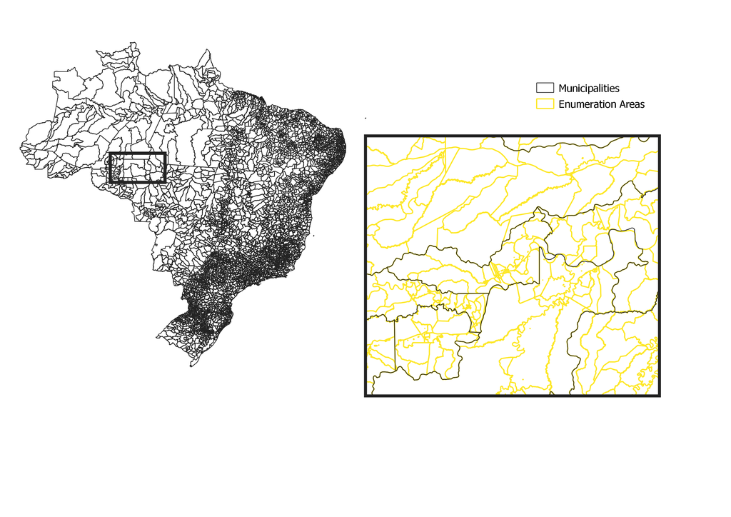

Figure 1: Example of enumeration area boundaries in Brazil

## Pre-requisites

The following software may be needed to complete this tutorial:

1. [R environment](https://www.r-project.org/),
2. [RStudio](https://rstudio.com/) (optional), and
3. [ArcGIS](https://www.esri.com/) or [QGIS](https://www.qgis.org/) (optional to view results).

The following pre-requisite skills may be helpful:

1. R programming language
   - install packages, load and manipulate data
2. Machine learning concepts
   - predictor and response variables, model diagnostics
3. GIS concepts
   - raster and vector data, zonal statistics

# Background

The modelling process consists of three steps (Fig. 2):

1. Estimate the relationship between population density and geospatial covariates at the municipality level,
2. Predict population densities at the level of enumeration areas using the covariates, and
3. Use predicted densities as a weighting layer to disaggregate the population totals for municipalities.

The core product is the weighting layer that should reflect the spatial distribution of the population inside the municipalities. The final goal is to predict the population count in each enumeration area correctly.

The extent of the study area is defined by the spatial coverage of the municipalities for which we have population totals. The top-down method cannot estimate populations for enumeration areas within municipalities where population totals are unknown.

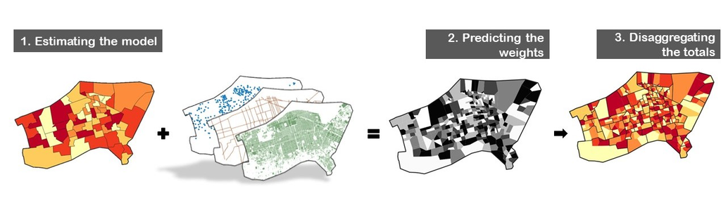

Figure 2: Modelling Process

Random forest is a machine learning algorithm that builds an ensemble of individual regression trees to predict values of a response variable (e.g. population density) based on its relationships with geospatial covariates (Breiman 2001; Stevens et al. 2015). Each regression tree identifies threshold values of the covariates that can be used to split the training data into fairly homogeneous groups (i.e. with similar population densities).

The algorithm prevents overfitting by withholding a subset of the training data for each individual tree that can be used to calculate rates of “out-of-bag” prediction error (i.e. out-of-sample cross-validation). The algorithm also prevents overfitting by randomly selecting a small set of covariates to be considered for splitting the training data at each node of the regression tree, rather than assessing all covariates at each split. These features make random forest fairly robust to multi-collinearity among covariates allowing it to use large sets of covariates without *a priori* variable selection. However, a large number of covariates might impact running time, especially at the prediction stage, and it may be useful to select a subset of covariates based on the measures of covariate importance provided by the random forest algorithm (Stevens et al. 2015; Bondarenko et al. 2018). While random forest predictions are robust to multi-collinearity among covariates, the measures of covariate importance may not be (Genuer, Poggi, and Tuleau-Malot 2010).

To dive deeper on the subject of random forest, here are some online materials:

- A use-R 2009 conference [presentation](https://www.r-project.org/conferences/useR-2009/slides/Cutler.pdf) given by Adele Cutler who developed the random forest algorithm with Leo Breiman.
- A 2019 [blog post](https://towardsdatascience.com/understanding-random-forest-58381e0602d2) by Tony Yiu with clear explanations of Random Forest main features namely *bagging* and *covariates randomness* that supports the creation of uncorrelated forest of decision trees.
- A 2001 [article](https://www.stat.berkeley.edu/~breiman/randomforest2001.pdf) from Breiman explaining the underlying maths.

The implementation we will provide in this tutorial will follow the guidance set up by Bondarenko et al. (2018) to apply random forest for top-down disaggregation.

# R Environment

This model will be implemented in the R programming language (R Core Team 2020). Our first step is to setup the R environment so that it contains the R packages and data that we will need. The `randomForest` package (Liaw and Wiener 2002) implements the random forest algorithm in R. If you have not already installed it, then you will need to install it.

```r
install.packages('randomForest')
```

Once installed, you must load the `randomForest` package into your R environment.

```r
library(randomForest)
```

We will define our working directory to be the location where we have stored the input data for the tutorial (`master_train.csv` and `master_predict.csv` described below).

```r
setwd('c:/myfolder')
```

## Source Data

This tutorial includes two input data sets, provided as csv spreadsheets (comma-separate-values text files):

1. **master_train.csv** Training data for the model that contains population totals and covariate values for 5568 municipalities in Brazil, and
2. **master_predict.csv** Prediction data for the model that contains covariate values for 444215 enumeration areas where population estimates are needed.

```r
# training data from municipalities
master_train <- read.csv("master_train.csv")
# covariates from enumeration areas
master_predict <- read.csv("master_predict.csv")
```

```r
head(master_train[,1:5]) # only showing first five columns
```

```
          name_muni geo_code     pop       area
1       Bras\xedlia  5300108 3055149 5779998938
2  Vila Prop\xedcio  5222302    5882 2181582535
3          Vila Boa  5222203    6312 1060171349
4 Vicentin\xf3polis  5222054    8873  737256139
5     Vian\xf3polis  5222005   13977  954283662
6         Varj\xe3o  5221908    3838  519194233
  mean.bra_viirs_100m_2016
1               8.51690292
2               0.08895954
3               0.07032987
4               0.13859431
5               0.17625734
6               0.09681950
```

```r
head(master_predict[,1:4]) # only showing first four columns
```

```
  EA_id geo_code mean.bra_viirs_100m_2016 mean.bra_srtm_slope_100m
1     1  1100015                21.700214                 1.954565
2     2  1100015                12.255162                 2.374444
3     3  1100015                18.794325                 1.983213
4     4  1100015                11.781239                 1.631729
5     5  1100015                 3.152316                 2.861502
6     6  1100015                 7.395526                 1.814885
```

Notice that only the municipality-level dataset `master_train.csv` contains a column for population. The EA-level dataset does not contain a column for population, and it is the goal of this tutorial to estimate those EA-level populations based on the EA-level covariates in `master_predict.csv`.

Also, notice that the column names for the covariates are exactly the same in the municipality-level dataset and the EA-level dataset. All of the municipality-level covariates used to train the model must also be available at the EA level for the model predictions.

The `geo_code` column contains a numeric identifier for each municipality and will be used in later steps to identify the municipality that each EA belongs to. Boundaries of enumeration areas in Brazil roughly follow municipality boundaries (i.e. enumeration areas are nested within municipalities), but the boundaries are not harmonized exactly. We assigned each enumeration area to the municipality that contained the majority of its area.

**Note:** We derived the two spreadsheets (`master_train.csv` and `master_predict.csv`) from the following sources:

1. Brazil’s [municipality boundaries](https://www.ibge.gov.br/en/geosciences/territorial-organization/regional-division/23708-brazilian-territorial-division.html?=&t=o-que-e) (IBGE 2019),
2. Brazil’s [2020 census projections](https://www.ibge.gov.br/en/statistics/social/18448-population-estimates.html?=&t=resultados) for municipalities (IBGE 2020b),
3. Brazil’s census EA boundaries (IBGE 2020a),
4. WorldPop’s mastergrid for Brazil (WorldPop and CIESIN 2018a), and
5. WorldPop’s geospatial covariate rasters for Brazil (Lloyd et al. 2019; Lloyd, Sorichetta, and Tatem 2017).

See the section Zonal Statistics for more information about how the input data were created.

# Random Forest

We will reformat the source data into the correct format for the random forest model before we fit the model and apply it to estimate populations in each enumeration area (EA). We will start by preparing the response and predictor variables from `master_train.csv` for training the model.

## Response Variable

The response variable `y_data` for our random forest model must be a vector with a population value for each municipality. We will define our response variable as the log of population density:

```r
y_data <- master_train$pop / master_train$area

y_data <- log(y_data)
```

We use log population density as the response variable rather than population counts for two main reasons. First, population densities are more comparable than counts among spatial units of varying sizes (e.g. municipalities and EAs). Second, the logarithm transformation reshapes the response variable as a Gaussian distribution, better inline with the distributions of covariates (Stevens et al. 2015) (Fig. 3). Note that `master_train$area` is measured in square meters in this case but any unit of area will work.

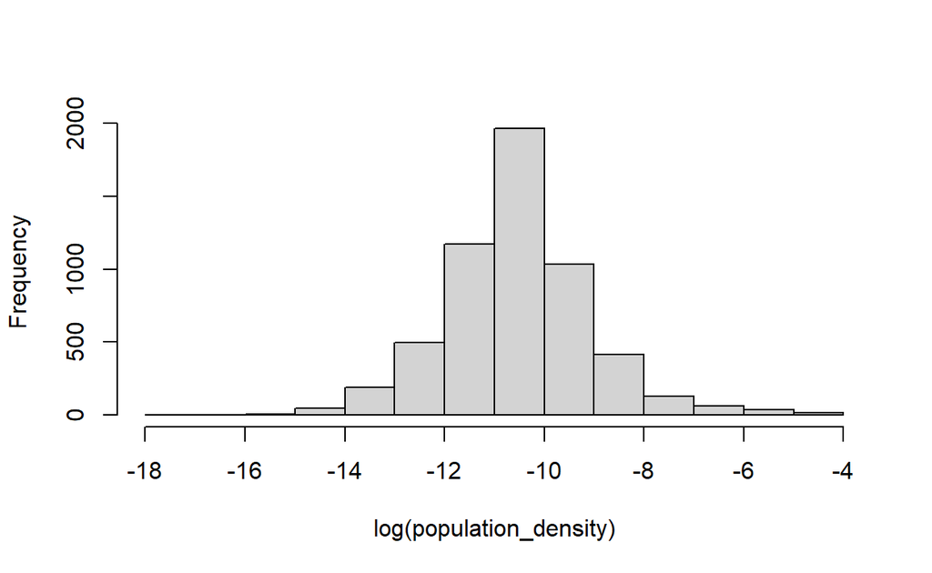

Figure 3: Histogram of the log-transformed population density.

We now have `y_data`, a vector with the log population density for every municipality in Brazil.

## Predictor Variables

The predictor data `x_data` for our random forest model must be a data.frame with a row for each municipality and a column for each covariate. The row order must match that of `y_data` (i.e. row 1 from `x_data` must represent the same enumeration area as element 1 from `y_data`).

We build the predictor data `x_data` by subsetting the covariates from `master_train.csv` that we would like to include in our model. Remember, we want to select covariates that will be good predictors of log population density.

```r
# list all covariate names (i.e. column names)
cols <- colnames(master_train)
print(cols)
```

```
 [1] "name_muni"
 [2] "geo_code"
 [3] "pop"
 [4] "area"
 [5] "mean.bra_viirs_100m_2016"
 [6] "mean.bra_srtm_slope_100m"
 [7] "mean.bra_osm_dst_road_100m_2016"
 [8] "mean.bra_esaccilc_dst200_100m_2015"
 [9] "mean.bra_esaccilc_dst190_100m_2015"
[10] "mean.bra_esaccilc_dst150_100m_2015"
[11] "mean.bra_esaccilc_dst140_100m_2015"
[12] "mean.bra_esaccilc_dst130_100m_2015"
[13] "mean.bra_esaccilc_dst040_100m_2015"
[14] "mean.bra_esaccilc_dst011_100m_2015"
[15] "code_state"
[16] "code_muni"
[17] "abbrev_state"
```

Our example data `master_train.csv` includes a few columns that are not covariates (e.g. `geo_code`) and so we do not want to include them in `x_data`. Our covariates all include the word “mean” in their column names because they were calculated as the mean value of underlying covariate rasters within each municipality. So, we will use “mean” as a search term to identify the correct columns. This provides an example of selecting a subset of the predictors, but you could use other subsets, search terms, or methods of subsetting.

```r
# select column names that contain the word 'mean'
cov_names <- cols[grepl('mean', cols)]
print(cov_names)
```

```
 [1] "mean.bra_viirs_100m_2016"
 [2] "mean.bra_srtm_slope_100m"
 [3] "mean.bra_osm_dst_road_100m_2016"
 [4] "mean.bra_esaccilc_dst200_100m_2015"
 [5] "mean.bra_esaccilc_dst190_100m_2015"
 [6] "mean.bra_esaccilc_dst150_100m_2015"
 [7] "mean.bra_esaccilc_dst140_100m_2015"
 [8] "mean.bra_esaccilc_dst130_100m_2015"
 [9] "mean.bra_esaccilc_dst040_100m_2015"
[10] "mean.bra_esaccilc_dst011_100m_2015"
```

```r
# subset the data.frame to only these columns
x_data <- master_train[,cov_names]
head(x_data[,1:2]) # only showing first two columns
```

```
  mean.bra_viirs_100m_2016 mean.bra_srtm_slope_100m
1               8.51690292                 3.547058
2               0.08895954                 4.198463
3               0.07032987                 3.522752
4               0.13859431                 1.620756
5               0.17625734                 3.577609
6               0.09681950                 5.659529
```

We now have a data.frame `x_data` with a row for each municipality and a column for each covariate.

## Model Fitting

The model fitting process will identify relationships between the response variable (i.e. population) and predictor variables at the municipality level.

### Settings

Before running the random forest model, we need to identify appropriate values for each argument of the `randomForest()` and/or `tuneRF()` functions. See `?randomForest` and `?tuneRF` for detailed descriptions of all arguments to the functions.

A critical argument in `randomForest()` function is `mtry`, the number of randomly selected variables for evaluating the best split at each node in a regression tree within the random forest model. This process is at the root of the randomness in *random* forest models. To find the optimal `mtry` value, we use the function `tuneRF()` that compares different models based on their “out-of-bag” error rates.

**Note:** Out-of-bag error is a form of cross-validation that is calculated by comparing model predictions to observed data from EAs that were randomly selected to be witheld from model fitting (i.e. held “out-of-bag”) for an iteration of the model (i.e. a single regression tree in the random forest model).

During each iteration of a random forest model, a regression tree is fit to a random sub-sample of the data. This prevents overfitting and also provides a built-in mechanism for cross-validation. The `sampsize` argument sets the sample size, and the `replace` argument defines the sampling strategy. In our case, we will define `sampsize` as the total count of observations (i.e. 5568 municipalities) and `replace` will be `TRUE` to sample *with replacement* from the training data.

Our specifications for other parameters follow Bondarenko et al. (2018).

- **ntree**: Number of trees to grow. There is no issue of overfitting when adding additional trees. We opt for 500, the default value of the `randomForest()` function.
- **importance**: If `TRUE`, the model will calculate the covariate importance for further analysis. We opt for `TRUE`.
- **nodesize**: Minimum size of the terminal node of the trees controls the tree complexity. We make it about 0.1% of the training data sample size (i.e. 5).

### Run the Model

Once we have decided on appropriate settings, we will input them as arguments to the `tuneRF()` function (note: this may take several minutes to run).

```r
# model fitting
popfit <- tuneRF(
  x=x_data,
  y=y_data,
  plot=TRUE,
  mtryStart=length(x_data)/3,
  ntreeTry=500,
  improve=0.0001, # threshold on the OOB error to continue the search
  stepFactor=1.20, # incremental improvement of mtry
  trace=TRUE,
  doBest=TRUE, # last model trained with the best mtry
  nodesize=length(y_data)/1000,
  na.action=na.omit,
  importance=TRUE, # calculate variable importance
  sampsize=length(y_data), # size of the sample to draw for OOB
  replace=TRUE
                 ) # sample with replacement
```

The `popfit` object contains the fitted random forest model. We can see the items within the object:

```r
names(popfit)
```

```
 [1] "call"            "type"            "predicted"
 [4] "mse"             "rsq"             "oob.times"
 [7] "importance"      "importanceSD"    "localImportance"
[10] "proximity"       "ntree"           "mtry"
[13] "forest"          "coefs"           "y"
[16] "test"            "inbag"
```

We can retrieve individual values, such as the value of the `mtry` setting that was selected by the `tuneRF` function.

```r
popfit$mtry
```

```
[1] 4
```

See the “Value” section in the help for the randomForest function `?randomForest::randomForest` for an explanation of each value.

We will now save the `popfit` object to our hard drive.

```r
save(popfit, file='popfit.Rdata')
```

We can load the fitted model back into our R environment later using:

```r
load('popfit.Rdata')
```

## Weighting Layer

We will use the fitted model to create a weighting layer that will be used to redistribute the population totals for municipalities into the enumeration areas (EA) within them. The EA-level covariate data `master_predict.csv` contains 444215 rows, one for each EA in Brazil.

We will first use the fitted random forest model to generate raw model predictions for each EA and save them as a column in the `master_predict` data.frame:

```r
# random forest predictions
master_predict$predicted <- predict(
  popfit,
  newdata = master_predict
  )
```

The weights are then calculated from the model predictions using the following formula:

$$\begin{equation}
weight_{i} = \frac{exp(predicted_{i})}{\sum_{i=1}^{I_j}{exp(predicted_{i})}}
\tag{1}
\end{equation}$$

where $predicted_i$ is the model prediction for enumeration area $i$, and $I_j$ is the total number of enumeration areas in municipality $j$. These weights represent the proportion of the population from municipality $j$ that lives in enumeration area $i$.

## Redistribution to EA-level

We will now use the weights to estimate the population for each enumeration area $i$ using the following formula:

$$\begin{equation}
population_{i} = total_j \times weight_{i}
\tag{2}
\end{equation}$$

where $total_j$ is the population total for municipality $j$ and $weight_i$ is the proportion of the population that lives in enumeration area $i$ (Eq. (1)). We will now work through this formula step-by-step in R.

First, we will exponentiate the predictions (numerator from Eq. (1)) and save them as a column in `master_predict`:

```r
# back-transform predictions to natural scale
master_predict$predicted_exp <- exp(
  master_predict$predicted
  )
```

We need to exponentiate the predictions because we log-transformed the population densities that we used as the response variable for training the model. Therefore, the model predictions are population densities on the log-scale. We exponentiate them to derive the predicted population densities that we will use as weighting factors to disaggregate the municipality-level population totals.

Next, we will sum the predicted population densities among EAs in each municipality (denominator from Eq. (1)) and merge the results into `master_predict` using the `geo_code` column to match municipalities:

```r
# sum exponentiated predictions among EAs in each municipality
predicted_exp_sum <- aggregate(list(predicted_exp_sum=master_predict$predicted_exp),
                               by = list(geo_code=master_predict$geo_code),
                               FUN = sum)

# merge predicted_exp_sum into master_train based on geo_code
master_predict <- merge(master_predict,
                        predicted_exp_sum,
                        by='geo_code')
```

These sums (i.e. the denominator from Eq. (1)) are used to scale the exponentiated model predictions to sum to one among EAs in each municipality.

Then, we will merge the total populations for each municipality into `master_predict`, again using the `geo_code` column to match EAs to the correct municipalities:

```r
# merge municipality total populations from master_train into master_predict
master_predict <- merge(master_predict,
                        master_train[,c('geo_code','pop')],
                        by = 'geo_code')

# modify column name
names(master_predict)[ncol(master_predict)] <- 'pop_municipality'
```

We have now added all of the required information from Eqs. (2) and (1) into the `master_predict` data.frame. We will calculate the EA-level population estimates and add them to `master_predict` as a column:

```r
# calculate EA-level population estimates
master_predict$predicted_pop <- with(master_predict, predicted_exp / predicted_exp_sum * pop_municipality)
```

Notice that this line of code is equivalent to Eqs. (2) and (1).

We have now disaggregated the population totals from 5568 municipalities in Brazil into population estimates for 444215 enumeration areas (Fig. 4).

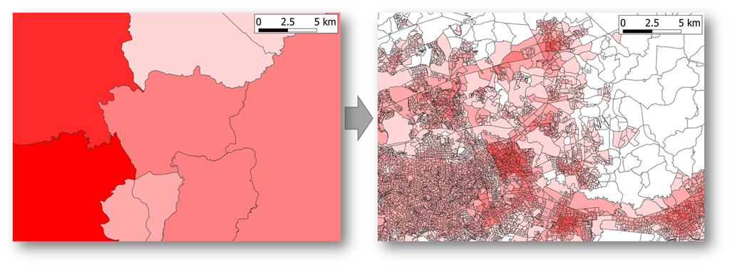

Figure 4: Census-based population totals for municipalities (left) that have been disaggregated into population estimates for enumeration areas (right) east of Sao Paulo, Brazil. Darker red corresponds to more people.

## Diagnostics

### Summing Enumeration Areas

We first want to check that the EA-level population estimates sum to the municipality-level population totals. To do this, we will aggregate the EA-level predictions using the `geo_code` column to identify the municipalities that each EA belongs to:

```r
# sum EA population estimates within each municipality
test <- aggregate(master_predict$predicted_pop,
                  by = list(geo_code=master_predict$geo_code),
                  FUN = sum)

# modify column names
names(test) <- c('geo_code','predicted_pop')

# merge municipality population totals
test <- merge(test,
              master_train[,c('geo_code','pop')],
              by = 'geo_code')

# test if estimates match muncipality population totals
all(test$pop == round(test$predicted_pop))
```

```
[1] TRUE
```

If we fail this test (i.e. if the last line of code returns a value of FALSE), it could mean that there was an error in our implementation of Eq. (2) or Eq. (1) because those equations should re-scale the EA-level population estimates so that they always sum to the population totals for each municipality. This test does not assess the goodness-of-fit for the random forest model.

### Goodness-of-Fit

The `print` function from the randomForest package displays two metrics that describe the out-of-bag prediction residuals:

- the mean squared residuals (MSE)
- the % of variance explained which corresponds to a pseudo $R^2$, (1 - MSE/ Var(`y_data`)).

The first metric (MSE) is dependent on the scale of the input response variable (e.g. the unit of area used to calculate population density), whereas the second metric ($R^2$) can be compared across models with different response variables.

```r
# goodness-of-fit metrics
print(popfit)
```

```
Call:
 randomForest(x = x, y = y, mtry = res[which.min(res[, 2]), 1],      replace = TRUE, sampsize = ..4, nodesize = ..1, importance = TRUE,      na.action = ..2)
               Type of random forest: regression
                     Number of trees: 500
No. of variables tried at each split: 4

          Mean of squared residuals: 0.2089229
                    % Var explained: 89.97
```

We can visualize the out-of-bag predictions for municipalities.

First we plot the observed vs predicted values. This enables us to spot any municipalities where the random forest predictions are not accurate.

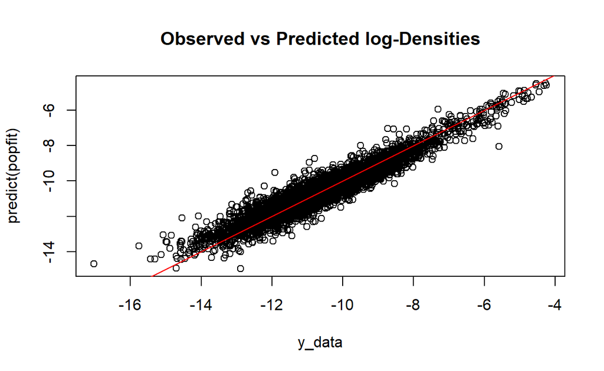

```r
# plot observed vs predicted (out-of-bag)
plot(x = y_data,
     y = predict(popfit),
     main = 'Observed vs Predicted log-Densities')

# 1:1 line
abline(a=0, b=1, col='red')
```

**Note:** The predict function in this code will return “out-of-bag” predictions (i.e. weights) for every municipality because we did not give it a new prediction data set, like we did in the section Weighting Layer (see`?predict.randomForest` for more info). The “out-of-bag” prediction for a municipality is generated from the regression trees of the model that did not include that municipality in their randomly sampled training data. This provides a cross-validation (a.k.a. out-of-bag, or out-of-sample) assessment.

Plotting the residuals versus the predictions allows us to detect any pattern towards over or underestimation.

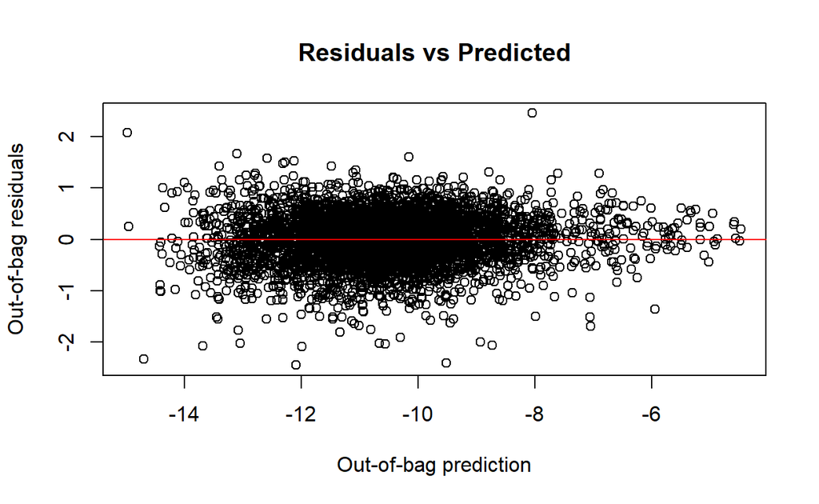

```r
# plot residuals (out-of-bag)
plot(x = predict(popfit),
     y = y_data - predict(popfit),
     main = 'Residuals vs Predicted',
     ylab = 'Out-of-bag residuals',
     xlab = 'Out-of-bag prediction')

# horizontal line at zero
abline(h=0, col='red')
```

**Important Note:** The different goodness-of-fit diagnostics presented here are focused on the training dataset and thus on predicting at the municipality level, but remember that the final goal is to predict at the enumeration area level.

### EA-level Assessment

There are two ways to evaluate the disaggregation results at the EA-level:

1. Comparing to an independent sample of enumeration areas or any other fine-scale spatial units for which we know the population counts, or
2. Build a test model using aggregated population counts at a coarser resolution (e.g. state-level) and evaluating its predictions at the municipality level.

The first option relies on the availability of an additional dataset. Disaggregating population estimates into 100 m grids rather than enumeration area polygons (as in this tutorial) would provide greater flexibility for aggregating units to match the spatial units of the independent validation data.

The second option is discussed by Stevens et al. (2015). Its effectiveness depends on the size of the aggregated training dataset (e.g. the number of states). Indeed a coarser scale means a decreasing number of input observations, which undermines the quantity of information the random forest can extract.

### Covariate Importance

We can look at the influence of individual covariates on model predictions. There are two measures of variable importance available. “Type 1” covariate importance is computed as the difference between out-of-bag mean squared error (MSE) from the full model compared to a model in which the variable is randomly permuted for each tree. If MSE is not affected by random permutations of the variable, then it has low importance according to this metric.

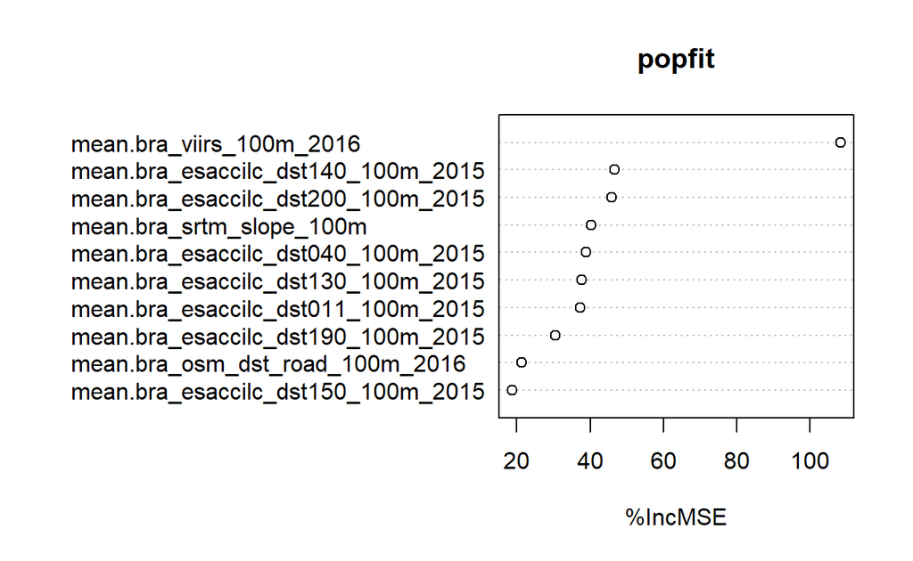

```r
# for covariate importance
varImpPlot(popfit, type=1)
```

“Type 2” covariate importance is computed as the total decrease in node purity when the variable is used for a split in the regression trees. Node purity is defined as the residual sum of squares among samples that are classified into the same terminal node of a regression tree. If splits in the tree based on this covariate do not decrease the residual sum of squares, then it has low importance according to this metric.

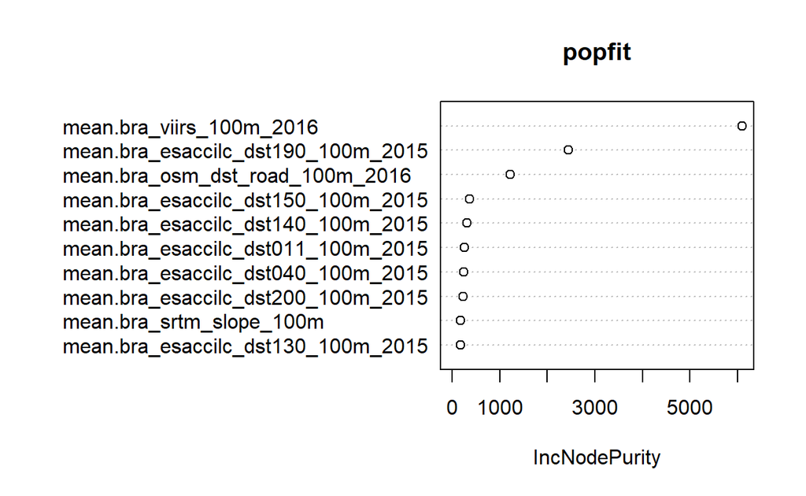

```r
# for covariate importance
varImpPlot(popfit, type=2)
```

See `?randomForest::importance` for more details.

**Note:** Use caution when interpreting covariate importance. A high importance value indicates that the covariate improves predictive performance, but does not indicate a causal relationship with spatial patterns of population density. Covariate importance scores may also be underestimated for large groups of correlated predictor variables.

# Limitations

1. **Random Forest can be time-intensive for large datasets.**

   If running time becomes an issue, there are several solutions that are outlined in the random forest set-up of Bondarenko et al. (2018).

   If the model takes too long to be fitted, one can play with the parameter `sampsize`, which has a great impact on modelling time or `ntreeSize`. Be careful though as a small number of trees can lead to overfitting. This issue can be clearly visible in any out-of-bag goodness-of-fit metrics.

   If the prediction takes too much time, Stevens et al. (2015) proposes to prune the number of covariates based on their importance metric. We have also provided an example of how to generate predictions more efficiently using parallel processing (see Parallel Processing section below).
2. **Random Forest models are not good at extrapolating.**

   They can only predict values that are in the range of observed values. This issue becomes a problem when the training and prediction inputs differ in range and distribution, which is known as *covariate shift*. The following plot can help detect a mismatch in covariates distribution between the two scales.

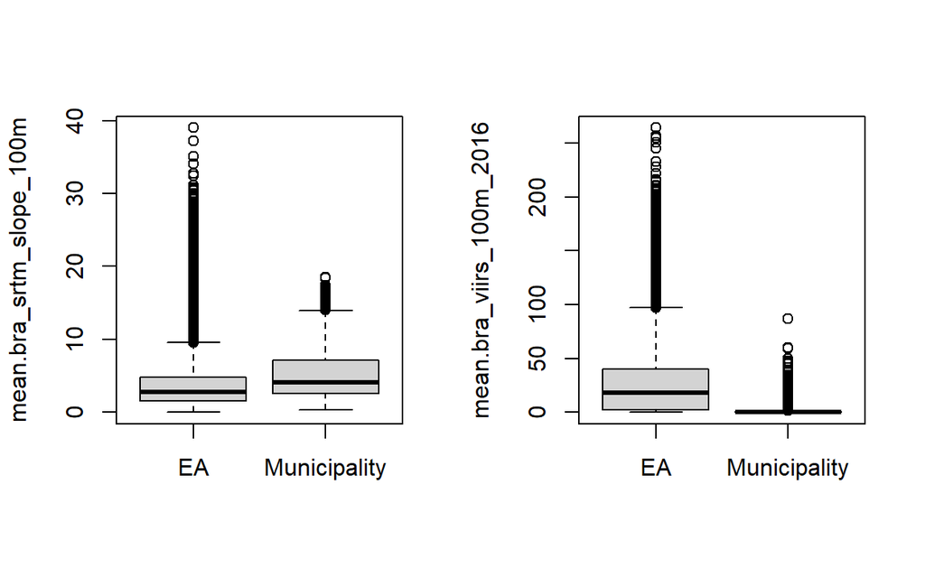

   Figure 5: The distributions of two covariates at each spatial scale: municipalities and enumeration areas. The left panel shows similar distributions across scales, but the right panel shows a covariate with significantly different distributions when measured for municipalities compared to enumeration areas.

   ```r
   # two panel layout
   layout(matrix(1:2, nrow=1))

   # loop through two covariates
   for(cov_name in c('mean.bra_srtm_slope_100m', 'mean.bra_viirs_100m_2016')){

     # combine EA-level and municipality-level values into a single vector
     y <- c(master_predict[,cov_name], master_train[,cov_name])

     # create corresponding vector identifying spatial scale
     x <- c(rep('EA', nrow(master_predict)),
        rep('Municipality', nrow(master_train)))

     # create boxplot
     boxplot(y~x, xlab=NA, ylab=cov_name)
   }
   ```

   Notice that the covariate `mean.bra_viirs_100m_2016` has a different range of values for EAs compared to municipalities (Fig. 5). This covariate measures the intensity of nighttime lights and we would expect its average values to be less in larger municipalities with large unsettled sections compared to small EAs, many of which are densely populated. This covariate was also the most influential on model predictions (see Covariate Importance). We may want to consider re-calculating this covariate using a mask to exclude unsettled areas within municipalities and EAs in an attempt to have a more comparable measure between spatial scales.
3. **Random Forest models are not ideal for inferring covariate effects.**

   The purpose of the modelling is to have a great predictive performance. We are not aiming at explaining the drivers of human spatial distribution. Therefore no causal effect should be derived from the modelling results.

# Tips and Tricks

The previous sections demonstrated the basic components of random forest top-down disaggregation, but there are additional tips and tricks that may be useful.

This section utilizes several source files that we did not include with the tutorial because they are large files that are publicly available from their original sources. These source files are:

1. Enumeration area boundaries for Brazil (IBGE 2020a),
2. VIIRS nighttime lights from 2016 (WorldPop and CIESIN 2018b), and
3. WorldPop mastergrid for Brazil (WorldPop and CIESIN 2018a).

**Note:** The code below will assume that these source files have been downloaded and unzipped (if applicable) into your working directory.

## Map Results

If you want to view the EA-level population estimates on a map (e.g. Fig. 4), you will need to join the model results (from section Redistribution to EA-level above) to polygon features for use with GIS software (e.g. Esri polygon shapefile).

For this step, we will need to install and load the `sf` package (Pebesma 2018) to read and manipulate GIS vector data (census EAs, in this case).

```r
install.packages('sf')
library('sf')
```

Then, we need to load a vector GIS data set containing the polygons that we would like to join our model results to. For this example, we are using Brazilian census enumeration area polygons which are openly available online as a polygon shapefile (IBGE 2020a).

```r
sf_polygons <- st_read('BR_Setores_2019.shp')
```

**Note:** The `st_read` function can read most GIS file formats (e.g. Esri shapefile, geopackage, geojson). See `?sf::st_read` for more information.

We will add an ID column that matches the enumeration area IDs from the `EA_id` column of the `master_predict` data.frame object (continuing from previous sections of this tutorial).

```r
sf_polygons$EA_id <- 1:nrow(sf_polygons)
```

Then, we can merge the `master_predict` data.frame which contains our EA-level population estimates into `sf_polygons`. We will use the `EA_id` column to match values to the correct enumeration area polygons.

```r
sf_polygons <- merge(sf_polygons,
                     master_predict,
                     by='EA_id')
```

Finally, we save the results to disk as an Esri shapefile.

```r
st_write(sf_polygons,
         'master_predict_polygons.shp')
```

This will save the result as an Esri shapefile because it uses the `.shp` file extension. If we want to save to a different format, we can simply modify the file extension. For example, we can save the result as a GeoPackage by adding the`.gpkg` file extension.

```r
st_write(sf_polygons,
         'master_predict_polygons.gpkg')
```

## Zonal Statistics

This tutorial began with two pre-processed spreadsheets `master_train.csv` and `master_predict.csv`. These input data were derived from raster-based covariates using zonal statistics to summarize raster values within each municipality and enumeration area using mean values or other summary statistics (e.g. median, mode, standard deviation, min, max). We will give a brief demonstration of how to do this.

We will rely on the `raster` and `exactextractr` packages (Hijmans 2020; Daniel Baston 2020) for this step and so we will first install and load those packages:

```r
install.packages(c('raster','exactextractr'))
library('raster')
library('exactextractr')
```

We already have polygon features `sf_polygons` loaded from the previous section (Map Results). We will also need to load a covariate raster. We will use a nighttime lights raster for Brazil that is openly available (WorldPop and CIESIN 2018b).

```r
raster_covariate <- raster('bra_viirs_100m_2016.tif')
```

Next, we will calculate a zonal mean within each enumeration area using the object `sf_polygons` (from section Map Results).

```r
sf_polygons$mean.bra_viirs_100m_2016 <- exact_extract(x = raster_covariate,
                                                      y = sf_polygons,
                                                      fun = 'mean')
```

Here, we saved the results into a new column of the `sf_polygons` data.frame called `mean.bra_viirs_100m_2016`.

**Note:** You may receive a warning message: `Polygons transformed to raster CRS (EPSG:NA)`. This indicates that the projection for `sf_polygons` was different than `raster_covariate`, and that a reprojection was performed internally by `exact_extract`. This does not affect our results, but we could have avoided the warning message by first reprojecting the covariate raster to match the polygons (see `?raster::projectRaster`) or by reprojecting the polygons to match the covariate raster (see `?sf::st_transform`).

After we have calculated all of the zonal statistics that we need, we can save the `sf_polygons` data.frame to disk as a csv spreadsheet.

```r
write.csv(st_drop_geometry(sf_polygons),
          file = 'EA_covariates.csv',
          row.names = FALSE)
```

This would be comparable to `master_predict.csv` that we used as input data for this tutorial. Note that the `st_drop_geometry()` function removes the polygon geometries from the `sf` object so that it is a simple data.frame with no spatial geometries (i.e. polygons) associated with each row. We could also save the results as an Esri shapefile to maintain the feature geometries.

```r
st_write(sf_polygons, 'EA_covariates.shp')
```

**Note:** The [exactextractr README](https://cran.r-project.org/web/packages/exactextractr/readme/README.html) also demonstrates a simple workflow to calculate zonal statistics for Brazilian municipalities.

## Gridded Population Estimates

In this tutorial, we disaggregated municipality-level population totals into finer resolution EA-level population estimates. We can also disaggregate population totals into grid cells (e.g. 100 m, 1 km). It is often easier to work with gridded population estimates because they can be aggregated to any areal units (e.g. census enumeration areas, administrative units, health facility catchment areas) and they may also be easier to compare to gridded data from other sources.

To do this, we need to create a new version of `master_predict.csv` where each row represents a grid cell rather than an enumeration area. We will start by loading a raster to use as a mastergrid that defines the locations and sizes of grid cells that we want to use.

```r
mastergrid <- raster('bra_level0_100m_2000_2020.tif')
```

This mastergrid raster for Brazil is publicly available from WorldPop (2018a). In this mastergrid, any cells that contain a value of NA are outside of Brazil.

Cell IDs for a raster are a numerical sequence starting from 1 in the top-left corner of the raster and increasing left-to-right. There are more than 2.5 billion grid cells in Brazil’s mastergrid and more than one billion contain non-NA values. We want to identify the cell IDs for all cells with a non-NA value. Because Brazil contains so many grid cells, we will subset the mastergrid for processing.

```r
cells <- which(!is.na(mastergrid[1:1e7]))
```

The new vector object `cells` will contain the cell IDs from the mastergrid that contain non-NA values. We are only processing the first 10 million grid cells (i.e. cells 1 to 1e7) in the mastergrid. We will continue the example using only this subset of the data to demonstrate how to generate gridded population estimates. In practice, we may want to process all of the grid cells at once (if computing power allows) or loop through one subset of cell IDs at a time (e.g. using a for loop) until all cell IDs are processed.

We will now setup a data.frame with a column for the cell IDs.

```r
mastergrid_predict <- data.frame(row.names = cells)
```

Next, we will use the same covariate raster `raster_covariate` from the previous section (Zonal Statistics) (WorldPop and CIESIN 2018b). This raster has the exact same extent and cell size as the mastergrid. Because the two rasters have identical extent and cell size, their cell IDs are comparable allowing us to use our vector of cell IDs `cells` to extract values very quickly and save them as a new column in the data.frame `master_predict`.

```r
mastergrid_predict[cells, 'bra_viirs_100m_2016'] <- raster_covariate[cells]
```

If the extent and cell size of a covariate raster do not match, then we can extract values from the covariate raster using the point coordinates associated with each grid cell rather than using cell IDs, but this is a slower process.

```r
# XY coordinates of each grid cell
xy <- xyFromCell(mastergrid, cells)

# extract raster values at those coordinates
mastergrid_predict[cells, 'bra_viirs_100m_2016_alt'] <- extract(raster_covariate, xy)
```

**Note:** Another option would be to resample the covariate raster to match the mastergrid, but exploring the different options for resampling is beyond the scope of this tutorial (see `?raster::resample` for more information).

We can then save the results as a csv spreadsheet.

```r
write.csv(mastergrid_predict,
          file = 'mastergrid_predict.csv',
          row.names = FALSE)
```

This spreadsheet could be used in exactly the same way as `master_predict.csv` was used above to generate model predictions (see section Weighting Layer). Because there are so many grid cells in Brazil where predictions are needed we would likely want to use parallel processing to speed up the calculations (see Parallel Processing section below). With either approach, we would generate a new column called `predicted_pop` in the `master_predict` data.frame that would contain the population estimates for each grid cell.

After we have these model predictions in tabular form in `master_predict`, we would then want to rasterize those results. First, we create an empty raster.

```r
raster_predict <- raster(mastergrid)
```

Then, we insert the population estimates into the raster based on the cell IDs of the predicted values.

```r
raster_predict[cells] <- mastergrid_predict[cells, 'predicted_pop']
```

If we are processing the cells in different subsets (i.e. using a for loop), we can repeat this step on the same raster using different sets of cell IDs until the raster is fully populated.

Finally, we can save the rasterized results to disk as a geotiff raster.

```r
writeRaster(raster_predict,
            file = 'raster_predict.tif')
```

## Parallel Processing

Parallel processing can improve processing speed when the study area contains a large number of spatial units where predictions are required (i.e. grid cells or polygons). For parallel processing, we will split the data into chunks that will be processed simultaneously using all of the processing cores available in our computer. The process that we described above to generate model predictions (see section Weighting Layer) used only a single processing core even if your computer had four or more cores available.

In the example from the previous section (Gridded Population Estimates), we saw that Brazil contained more than one billion grid cells where we would need model predictions. This would likely require parallel processing to generate model predictions efficiently. For a simple and efficient example, we will demonstrate parallel processing using the EA-level data in `master_predict` that will allow you to explore the process easily. When you are comfortable with the process, it can also be applied to the much larger data set in `mastergrid_predict`.

For this task we will need the `doParallel` R package (Corporation and Weston 2020) so we will start by installing and loading that package.

```r
install.packages('doParallel')
library('doParallel')
```

We will need to create a new R function that will generate model predictions. In the parallel processing steps that will follow, this function will be passed to a processing core along with a chunk of the data to generate predictions.

```r
predict_pop <- function(df, model=popfit){

  # EA-level predictions
  prediction <- predict(model, newdata = df)

  # back-transform to population density
  density <- exp(prediction)

  # calculate weights
  weights <- density / sum(density)

  # disaggregate municipality total to EA-level
  pop <- weights * df$pop_municipality[1]

  # result to data.frame
  result <- data.frame(id=df$id, predicted_pop_parallel=pop)

  # return result
  return(result)
}
```

The `df` argument of the function will be a subset of rows from `master_predict` and the `model` argument is the fitted random forest object `popfit`. This function generates model predictions using the `predict` function from the `randomForest` package and then it back-transforms the predicted log-densities to the natural scale. It then calculates weights from those densities and multiplies the weights by the total population for the municipality that each grid cell belongs to (note: these are the same steps as in section Redistribution to EA-level). The results are returned as a data.frame with an “id” column and a column containing the predictions.

Now, we will add an “id” column into `master_predict` that we will later use to merge the predictions back into this data.frame.

```r
master_predict$id <- 1:nrow(master_predict)
```

Next, we will break the `master_predict` data.frame into chunks that will be stored as elements in a list object.

```r
list_master_predict <- split(x = master_predict,
                             f = master_predict$geo_code)
```

Notice that we have used the `geo_code` column in `master_predict` to define the chunks. Remember, that `geo_code` identifies each municipality, so we will be processing each municipality separately. This simplifies the steps that are required in the predict function (above) because all units processed in a chunk use the same municipality-level total population (i.e. `df$pop_municipality[1]`). The new object `list_master_predict` is a list with an element for each municipality that contains a data.frame with a row for each spatial unit within that municipality.

Now, we must setup parallel processing by identifying the number of cores available, assigning them to a processing cluster, and activating the cluster.

```r
cores <- detectCores()

cluster <- makeCluster(cores)

registerDoParallel(cluster)
```

Then, we can run the predictions in parallel using this cluster.

```r
predicted <- foreach(i = 1:length(list_master_predict),
                     .combine = 'rbind',
                     .packages = c("randomForest")) %dopar%
  predict_pop(df = list_master_predict[[i]])

stopCluster(cluster)
```

This code will pass each element `i` from `list_master_predict` to our predict function `predict_pop()` and then combine the resulting data.frames using the `rbind()` function. The last line of code simply deactivates our cluster of processing cores.

The last step is to merge the results back into our original data.frame `master_predict` using the `id` column that we setup earlier.

```r
master_predict <- merge(master_predict,
                        predicted,
                        by = 'id')
```

**Note:** We have demonstrated parallel processing using the EA-level data in `master_predict`. It is important to note that EA-level predictions do not take too long to compute using the simpler approach (see section Weighting Layer). We recommend parallel processing only for larger tasks like generating gridded predictions from `mastergrid_predict`. We did not use this data in our example because it would potentially introduce complications that would distract from the demonstration of parallel processing, but the workflow that we demonstrated should be easily adaptable to accommodate any larger data sets.

# Contributions

This tutorial was written by Doug Leasure and Edith Darin from the WorldPop Research Group at the University of Southampton with oversight from Andy Tatem. This work was part of a WorldPop collaboration with the Brazilian Institute of Geography and Statistics (IBGE), United Nations Population Fund (UNFPA), and the Environmental Systems Research Institute (Esri). Attila Lazar and Chris Jochem provided internal reviews that helped improve the tutorial.

# Tutorial’s citation

Leasure DR, Darin E, Tatem AJ. 2020. Small area population estimates using random forest top-down disaggregation: An R tutorial. WorldPop, University of Southampton. doi:10.5258/SOTON/WP00697.

Bondarenko, Maksym, Jeremiah Nieves, Alessandro Sorichetta, Forrest R Stevens, Andrea E Gaughan, Andrew Tatem, and others. 2018. *wpgpRFPMS: WorldPop Random Forests population modelling R scripts, version 0.1.0*. WorldPop, University of Southampton. https://doi.org/10.5258/SOTON/WP00665.

Breiman, Leo. 2001. “Random Forests.” *Machine Learning* 45 (1): 5–32. https://doi.org/10.1023/A:1010933404324.

Corporation, Microsoft, and Steve Weston. 2020. *doParallel: Foreach Parallel Adaptor for the ’Parallel’ Package*. https://CRAN.R-project.org/package=doParallel.

Daniel Baston. 2020. *exactextractr: Fast Extraction from Raster Datasets Using Polygons*. https://CRAN.R-project.org/package=exactextractr.

Genuer, Robin, Jean-Michel Poggi, and Christine Tuleau-Malot. 2010. “Variable Selection Using Random Forests.” *Pattern Recognition Letters* 31 (14): 2225–36. https://doi.org/10.1016/j.patrec.2010.03.014.

Hijmans, Robert J. 2020. *raster: Geographic Data Analysis and Modeling*. https://CRAN.R-project.org/package=raster.

IBGE. 2019. *Brazilian Territorial Division, 2019 Edition*. Brazilian Institute of Geography and Environment (IBGE). https://www.ibge.gov.br/en/geosciences/territorial-organization/regional-division/23708-brazilian-territorial-division.html?=&t=o-que-e.

———. 2020a. *Meshes of Census Sectors Intra-Municipal Divisions*. Brazilian Institute of Geography and Environment (IBGE). http://geoftp.ibge.gov.br/organizacao_do_territorio/malhas_territoriais/malhas_de_setores_censitarios__divisoes_intramunicipais/2019/Malha_de_setores_(shp)_Brasil/.

———. 2020b. *Population Estimates - Tables 2020*. Brazilian Institute of Geography and Environment (IBGE). https://www.ibge.gov.br/en/statistics/social/18448-population-estimates.html?=&t=resultados.

Liaw, Andy, and Matthew Wiener. 2002. “Classification and Regression by randomForest.” *R News* 2 (3): 18–22. https://cran.r-project.org/package=randomForest.

Lloyd, Christopher T, Heather Chamberlain, David Kerr, Greg Yetman, Linda Pistolesi, Forrest R Stevens, Andrea E Gaughan, et al. 2019. “Global Spatio-Temporally Harmonised Datasets for Producing High-Resolution Gridded Population Distribution Datasets.” *Big Earth Data* 3 (2): 108–39.

Lloyd, Christopher T, Alessandro Sorichetta, and Andrew J Tatem. 2017. “High Resolution Global Gridded Data for Use in Population Studies.” *Scientific Data* 4 (1): 1–17.

Pebesma, Edzer. 2018. “Simple Features for R: Standardized Support for Spatial Vector Data.” *The R Journal* 10 (1): 439–46. https://doi.org/10.32614/RJ-2018-009.

R Core Team. 2020. *R: A Language and Environment for Statistical Computing*. Vienna, Austria: R Foundation for Statistical Computing. https://www.R-project.org/.

Sorichetta, Alessandro, Graeme M. Hornby, Forrest R. Stevens, Andrea E. Gaughan, Catherine Linard, and Andrew J. Tatem. 2015. “High-resolution gridded population datasets for Latin America and the Caribbean in 2010, 2015, and 2020.” *Scientific Data* 2 (1): 1–12. https://doi.org/10.1038/sdata.2015.45.

Stevens, Forrest R., Andrea E. Gaughan, Catherine Linard, and Andrew J. Tatem. 2015. “Disaggregating Census Data for Population Mapping Using Random Forests with Remotely-Sensed and Ancillary Data.” *PLOS ONE* 10 (2): e0107042. https://doi.org/10.1371/journal.pone.0107042.

WorldPop, and CIESIN. 2018a. *Administrative Areas: National Boundaries, Brazil*. WorldPop, University of Southampton. https://doi.org/10.5258/SOTON/WP00651.

———. 2018b. *Geospatial covariate data layers: VIIRS night-time lights (2012-216), Brazil*. WorldPop, University of Southampton. https://doi.org/10.5258/SOTON/WP00644.